# Logistic Regression

Lecture 08

February 9, 2026

# Review

## Linear Regression

Linear regression as probability model:
$$y = \sum_i \beta_i x_i + \varepsilon_i, \quad \varepsilon_i \sim N(0, \sigma^2)$$

- Maximum likelihood gives same parameters as OLS
- Allows us to determine conditional predictive probability $p(Y | X=\mathbf{x})$
- Can get other insights: sampling distributions, confidence intervals, etc.

## More on Predictive Intervals

$1-\alpha$-predictive intervals:

- Contain $1-\alpha\%$ of predicted values
- Typically conditional $p(Y | X=\mathbf{x})$
- Can be unconditional if we know $p(X)$:
  $$p(Y) = \int_X p(Y | X=\mathbf{x}) p(\mathbf{x}) dx$$

## Generating Predictive Intervals for LR

- $p(Y | X=\mathbf{x}) = N(\sum_i \beta_i x_i, \sigma^2)$
- Due to homoskedasticity, get $\alpha/2$ and $1 - \alpha/2$ quantiles for error distribution $N(0, \sigma^2)$
- Center this interval on $\mathbf{E}(Y | \mathbf{x}) = \sum_i \beta_i x_i$
- Can also generate by **simulation** (more general approach).

## Example: Simulating Prediction Intervals

```julia
# load data
tds = let
    fname = "data/tds/cuyaTDS.csv" # CHANGE THIS!
    tds = DataFrame(CSV.File(fname))
    tds[!, [:date, :discharge_cms, :tds_mgL]]
end

# fit model
function tds_riverflow_loglik(θ, tds, flow)
    β₀, β₁, σ = θ # unpack parameter vector
    μ = β₀ .+ β₁ * log.(flow) # find mean
    ll = sum(logpdf.(Normal.(μ, σ), tds)) # compute log-likelihood
    return ll
end

lb = [0.0, -1000.0, 1.0]
ub = [1000.0, 1000.0, 100.0]
θ₀ = [500.0, 0.0, 50.0]
optim_out = Optim.optimize(θ -> -tds_riverflow_loglik(θ, tds.tds_mgL, tds.discharge_cms), lb, ub, θ₀)
θ_mle = round.(optim_out.minimizer; digits=0)

# simulate 10,000 predictions
x = 1:0.1:60
μ = θ_mle[1] .+ θ_mle[2] * log.(x)

y_pred = zeros(length(x), 10_000)
for i = 1:length(x)
    y_pred[i, :] = rand(Normal(μ[i], θ_mle[3]), 10_000)
end
# take quantiles to find prediction intervals
y_q = mapslices(v -> quantile(v, [0.05, 0.5, 0.95]), y_pred; dims=2)
```

## Resulting Prediction Intervals

```julia
p = scatter(
    tds.discharge_cms,
    tds.tds_mgL,
    xlabel=L"Discharge (m$^3$/s)",
    ylabel="Total dissolved solids (mg/L)",
    markersize=5,
    label="Observations",
    size = (1100, 500)
)
plot!(x,
    μ,
    ribbon = (y_q[:, 2] - y_q[:, 1], y_q[:, 3] - y_q[:, 2]),
    linewidth=3,
    fillalpha=0.2,
    label="Best Fit")
```

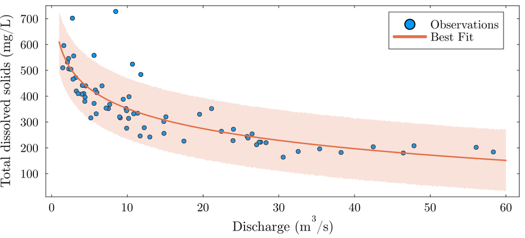

## Checking Assumptions

**Always check assumptions of probability model**.

In this case: are the residuals independently and normally distributed with constant variance?

If not:

1. Relationship might not be linear.
2. Might need different distribution for error distribution.

## Checking Assumptions

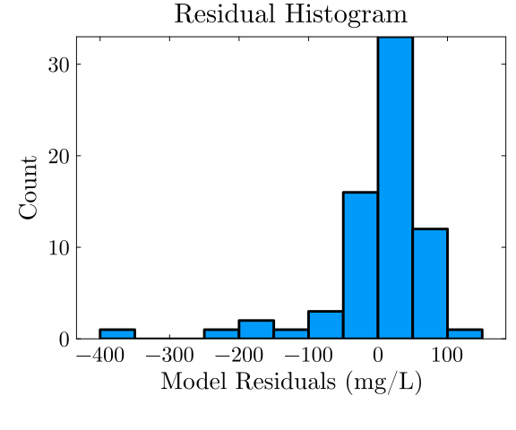

(a) Residuals for the TDS-Riverflow model.

[figure not shown]

(b)

Figure 2

# Logistic Regression

## Models for Classification

Suppose instead of predicting **values**, we want to predict membership in a **class**.

Examples:

- Will it snow in Ithaca tomorrow?
- Will we see a bird in a location?
- Will this person get heart disease in the next five years?

## Probability Model for Classification

Would like conditional distribution of the probabilities, $p(Y | X)$.

**Should we treat a prediction with a 51% of a classification the same as 90%?**

## Indicator Variables

For simplicity, assume our response variable $Y$ is binary: 0 or 1.

Such a variable is called an **indicator variable** (also sometimes used as predictors in linear regression).

Would like to model $\mathbb{E}[Y] = p(Y=1)$ or $\mathbb{E}[Y | X] = p(Y=1 | X)$.

## Approach to Modeling

We could model $Y$ as a linear regression. **Would this work**?

Instead, **what distribution might we use to model classification outcomes?**

## Bernoulli Distribution

“Recall” that a Bernoulli distribution models the outcome of a random indicator variable.

Consider a sequence of Bernoulli trials with constant probability of “success” ($Y=1$) $p$:

$$\mathcal{L}(p | Y = y_i, X = x_i) = \Pi_{i=1}^n p^{y_i}(1-p)^{1-y_i}$$

## Inhomogeneous Probabilities

We often want to know how covariates/predictors influence the classification probability.

This means we want to model:

$$\mathcal{L}(p_i | Y = y_i, X = \mathbf{x}_i) = \Pi_{i=1}^n p_i^{y_i}(1-p_i)^{1-y_i}$$

where $p_i = g(\mathbf{x}_i)$.

## How To Model Probabilities?

Some approaches:

1. Model $p_i$ as a linear regression in $x$. **Would this work**?
2. Use a transformation $f$ of $p$ which has unbounded range and domain $[0, 1]$,
   $$f(p): [0, 1] \to \mathbb{R}.$$

## Logit Function

Simplest function: **the logit (or logistic) function**

$$\text{logit}(p) = \log\left(\frac{p}{1-p}\right)$$

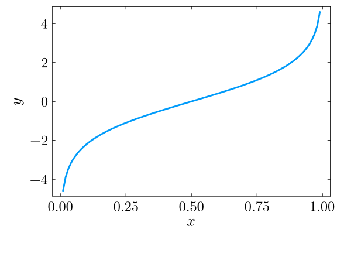

Figure 3: Logit Function

```julia
p = 0:0.01:1
logit(p) = log(p / (1 - p))
plot(p, logit.(p), xlabel=L"$x$", ylabel=L"$y$", linewidth=3, legend=false, size=(600, 450))
```

## Logistic Regression

This gives us the **logistic regression model**:

$$\text{logit}(p_i) = \sum_j \beta_j x^i_j$$

Solving for $p$:

$$p_i = \frac{\exp\left(\sum_j \beta_j x^i_j\right)}{1 + \exp\left(\sum_j \beta_j x^i_j\right)}.$$

Then we can predict the class when $p > p_\text{thresh}$, usually 0.5, or just work with probabilities.

## Assumptions for Logistic Regression

1. There is a **linear decision boundary**, $\sum_j x_j \beta_j = \text{logit}^{-1}(p_\text{thresh})$.
2. Class probabilities change as we move away from the boundary based on $\|\beta\|$.
3. The larger $\|\beta\|$, the smaller the change in $x$ required to move to the extremes.

## Interpretation of $\beta$

$$\log\left(\frac{p}{1-p}\right)$$
is called the **log-odds**.

$\exp^{\beta_i}$ tells us how much more likely the classification $Y=1$ is from a reference $x_i^1$ to $x_i^1 + 1$.

## Logistic Regression Likelihood

$$\begin{aligned}
\mathcal{L}(\beta_0, \beta) &= \Pi_{i=1}^n p(x_i)^{y_i} (1-p(x_i))^{1-y_i} \\
\mathcal{l}(\beta_0, \beta) &= \sum_{i=1}^n y_i \log p(x_i) + (1-y_i) \log (1-p(x_i)) \\
&= \sum_{i=1}^n \log (1-p(x_i)) + \sum_{i=1}^n y_i \log\left(\frac{p(x_i)}{1-p(x_i)}\right)
\end{aligned}$$

## Logistic Regression Log-Likelihood

$$\begin{aligned}
\mathcal{l}(\beta_0, \beta) &= \sum_{i=1}^n \log(1-p(x_i)) + \sum_{i=1}^n y_i(\beta_0 + \mathbf{x}_i \cdot \beta_i) \\
&= \sum_{i=1}^n -\log(1+\exp(\beta_0 + \mathbf{x}_i \cdot \beta_i)) + \sum_{i=1}^n y_i(\beta_0 + \mathbf{x}_i \cdot \beta_i)
\end{aligned}$$

## Maximum Likelihood

Now we can differentiate:

$$\begin{aligned}
\frac{\partial l}{\partial \beta_j} &= -\sum_{i=1}^n \frac{1}{1 + \exp(\beta_0 + \mathbf{x}_i \cdot \beta_i)}\exp(\beta_0 + \mathbf{x}_i \cdot \beta_i)x^i_j + \sum_{i=1}^n y_i x^i_j \\
&= \sum_{i=1}^n (y_i - p(x_i | \beta_0, \beta)) x^i_j
\end{aligned}$$

We need to use numerical optimization to find the zeroes of this!

## Multi-Class Logistic Regression

What if $Y$ can take on more than just two values?

We can still use logistic regression, just need to modify the setup.

Now each class $c$ will have its own intercept $\beta_0^c$ and coefficients $\beta^c$.

## Multi-Class Logistic Regression

Predicted probabilities:

$$p(Y = c | X = \mathbf{x}) = \frac{\exp\left(\beta_0^c + x \cdot \beta^c \right)}{\sum_c \exp\left(\beta_0^c + x \cdot \beta^c\right) }$$

Maximizing the likelihood is similar, but encoding each class as a different outcome and using a Categorical distribution.

# Key Points

## Logistic Regression

- Approach for **classification problems**.
- Models probability of class occurrence.
- Assumes a **linear decision boundary**.

# Upcoming Schedule

## Lectures

**Wednesday**: Generalized Linear Models

**Friday**: Quiz 1, wrap up week

## Assessments

**HW2 Released**: Due 2/20

**Quiz 1**: Friday, on material through today.